# Part 1 — Building the Frozen Inputs

This notebook walks through the Part-1 pipeline end to end:

| Step | Section | Output |
| --- | --- | --- |
| Connectome | 4b–4e | `W_dk68.npy`, `region_names.npy` |
| FTD atrophy | 5b | `atrophy_FTD.npy` *(pending)* |
| AD atrophy | 5c | `atrophy_AD.npy` *(pending)* |

All source code lives in `src/levers/data.py`. Once the four `.npy` files are written to `data/processed/` they are treated as **frozen inputs** — later analysis notebooks read them directly and never re-run this pipeline.

**Data source:** Budapest connectome v3 (HCP, 1064 subjects, Lausanne scale33 = 83 nodes)  
**Atlas:** Desikan–Killiany 68-region cortical parcellation (DK-68)  
**Weight:** mean number of streamlines across subjects, spectral-radius normalized

```python
import sys
from pathlib import Path

import numpy as np
import matplotlib.pyplot as plt
import matplotlib.ticker as ticker
import networkx as nx

# make src/ importable without an editable install
ROOT = Path('.').resolve().parent
sys.path.insert(0, str(ROOT / 'src'))

from levers.data import DK34, CANON, build_connectome

PROCESSED = ROOT / 'data' / 'processed'
RAW       = ROOT / 'data' / 'raw'
```

## 1 Load the processed connectome

If `data/processed/W_dk68.npy` already exists (built by `scripts/01_build_inputs.py`), we load it directly. Otherwise we run the pipeline here — this will take ~2 minutes while it reads 1064 GraphML files.

```python
W_path = PROCESSED / 'W_dk68.npy'
N_path = PROCESSED / 'region_names.npy'

if W_path.exists() and N_path.exists():
    W     = np.load(W_path)
    names = list(np.load(N_path, allow_pickle=True))
    print(f'Loaded from cache: {W_path}')
else:
    print('Cache missing — running pipeline (grab a coffee)...')
    graphml_dir = RAW / 'budapest_83.graphml'
    W, names = build_connectome(graphml_path=graphml_dir, out_dir=PROCESSED)

print(f'W shape      : {W.shape}')
print(f'Spectral rad : {np.max(np.linalg.eigvals(W).real):.6f}  (normalized to 1.0)')
print(f'Symmetric    : {np.allclose(W, W.T)}')
print(f'Non-zero edges: {(W > 0).sum() // 2}')
```

```
Loaded from cache: C:\Users\Sophi\critical-levers\data\processed\W_dk68.npy
W shape      : (68, 68)
Spectral rad : 1.000000  (normalized to 1.0)
Symmetric    : True
Non-zero edges: 1157
```

## 2 Connectome heatmap

The 68 regions are ordered left hemisphere first (rows/cols 0–33), then right (34–67). The block structure reflects inter- vs intra-hemispheric connectivity.

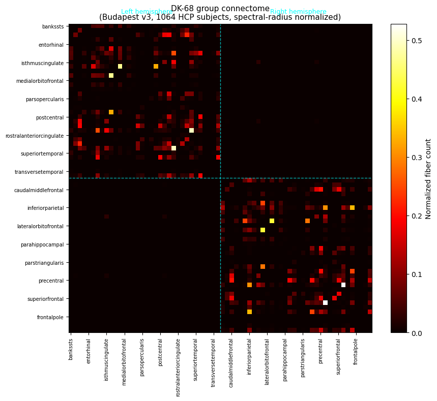

```
Figure saved to data/processed/W_dk68_heatmap.png
```

```python
fig, ax = plt.subplots(figsize=(9, 8))

im = ax.imshow(W, cmap='hot', aspect='auto', interpolation='nearest')
plt.colorbar(im, ax=ax, label='Normalized fiber count')

# hemisphere divider
ax.axhline(33.5, color='cyan', lw=1, ls='--', alpha=0.7)
ax.axvline(33.5, color='cyan', lw=1, ls='--', alpha=0.7)
ax.text(17, -2.5, 'Left hemisphere', ha='center', va='bottom', fontsize=9, color='cyan')
ax.text(51, -2.5, 'Right hemisphere', ha='center', va='bottom', fontsize=9, color='cyan')

# tick labels: bare region name every 4 rows to avoid crowding
tick_pos   = list(range(0, 68, 4))
tick_label = [names[i].split('_', 1)[1] for i in tick_pos]
ax.set_xticks(tick_pos); ax.set_xticklabels(tick_label, rotation=90, fontsize=7)
ax.set_yticks(tick_pos); ax.set_yticklabels(tick_label, fontsize=7)

ax.set_title('DK-68 group connectome\n(Budapest v3, 1064 HCP subjects, spectral-radius normalized)', fontsize=11)
fig.tight_layout()
plt.savefig(PROCESSED / 'W_dk68_heatmap.png', dpi=150, bbox_inches='tight')
plt.show()
print('Figure saved to data/processed/W_dk68_heatmap.png')
```

## 3 Degree distribution

Weighted node degree (sum of fiber counts per region) highlights which regions are structural hubs.

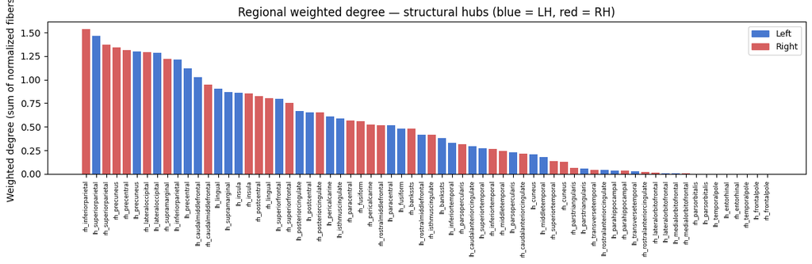

```python
degree = W.sum(axis=1)
order  = np.argsort(degree)[::-1]

fig, ax = plt.subplots(figsize=(12, 4))
colors = ['#4878CF'] * 34 + ['#D65F5F'] * 34   # blue=LH, red=RH
ax.bar(range(68), degree[order], color=[colors[i] for i in order], width=0.8)
ax.set_xticks(range(68))
ax.set_xticklabels([names[i] for i in order], rotation=90, fontsize=6)
ax.set_ylabel('Weighted degree (sum of normalized fibers)')
ax.set_title('Regional weighted degree — structural hubs (blue = LH, red = RH)')
from matplotlib.patches import Patch
ax.legend(handles=[Patch(color='#4878CF', label='Left'), Patch(color='#D65F5F', label='Right')], fontsize=9)
fig.tight_layout()
plt.savefig(PROCESSED / 'degree_distribution.png', dpi=150, bbox_inches='tight')
plt.show()
```

## 4 Region ordering (canonical DK-68 index)

Every vector in this project uses this exact ordering. Index 0–33 = left hemisphere, 34–67 = right.

```python
import pandas as pd

df = pd.DataFrame({
    'index': range(68),
    'name': names,
    'hemisphere': ['Left'] * 34 + ['Right'] * 34,
    'bare_region': [n.split('_', 1)[1] for n in names],
    'weighted_degree': degree,
})
df.set_index('index', inplace=True)
df.sort_values('weighted_degree', ascending=False).head(20)
```

| index | name | hemisphere | bare_region | weighted_degree |
| --- | --- | --- | --- | --- |
| 40 | rh_inferiorparietal | Right | inferiorparietal | 1.537263 |
| 27 | lh_superiorparietal | Left | superiorparietal | 1.464425 |
| 61 | rh_superiorparietal | Right | superiorparietal | 1.370946 |
| 57 | rh_precuneus | Right | precuneus | 1.341744 |
| 56 | rh_precentral | Right | precentral | 1.311702 |
| 23 | lh_precuneus | Left | precuneus | 1.298404 |
| 43 | rh_lateraloccipital | Right | lateraloccipital | 1.290776 |
| 9 | lh_lateraloccipital | Left | lateraloccipital | 1.288025 |
| 63 | rh_supramarginal | Right | supramarginal | 1.223296 |
| 6 | lh_inferiorparietal | Left | inferiorparietal | 1.216871 |
| 22 | lh_precentral | Left | precentral | 1.122009 |
| 2 | lh_caudalmiddlefrontal | Left | caudalmiddlefrontal | 1.023229 |
| 36 | rh_caudalmiddlefrontal | Right | caudalmiddlefrontal | 0.948690 |
| 11 | lh_lingual | Left | lingual | 0.906405 |
| 29 | lh_supramarginal | Left | supramarginal | 0.867574 |
| 33 | lh_insula | Left | insula | 0.861938 |
| 67 | rh_insula | Right | insula | 0.855931 |
| 54 | rh_postcentral | Right | postcentral | 0.823788 |
| 45 | rh_lingual | Right | lingual | 0.804128 |
| 26 | lh_superiorfrontal | Left | superiorfrontal | 0.798331 |

## 5 Basic graph statistics

```python
# threshold at > 0 for binary graph stats
G = nx.from_numpy_array(W)

print(f"Nodes                : {G.number_of_nodes()}")
print(f"Edges (W > 0)        : {G.number_of_edges()}")
print(f"Density              : {nx.density(G):.3f}")
print(f"Mean clustering coef : {nx.average_clustering(G, weight='weight'):.4f}")
print(f"Max edge weight      : {W.max():.4f}")
print(f"Mean edge weight (W>0): {W[W>0].mean():.4f}")

eigvals = np.linalg.eigvals(W).real
print(f"Spectral radius      : {eigvals.max():.6f}")
print(f"Second eigenvalue    : {np.sort(eigvals)[-2]:.6f}")
```

```
Nodes                : 68
Edges (W > 0)        : 1157
Density              : 0.508
Mean clustering coef : 0.0058
Max edge weight      : 0.5279
Mean edge weight (W>0): 0.0148
Spectral radius      : 1.000000
Second eigenvalue    : 0.920840
```

## Next steps

- **Section 5b** — parcellate `ftd_bvFTD_tmap.nii.gz` (Zenodo 10383493) onto DK-68 → `atrophy_FTD.npy`
- **Section 5c** — derive AD atrophy vector from ADNI cortical thickness tables → `atrophy_AD.npy`
- **Part 2+** — network control theory analysis using `W_dk68`, `atrophy_AD`, `atrophy_FTD`